# Bigram Relationships

Shannon Lo

19 Oct 2019

```r
library(tidyverse)
library(tidytext)
library(tm)
library(widyr)
library(igraph)
library(ggplot2)
library(ggraph)
library(readr)
library(tidygraph)
```

The following function(s) are defined below: * **visualize_bigrams**: extracts bigrams from a text field, calculates frequency of bigrams, and creates a bigram plot to visualize relationships between words + *df_name*: name of dataframe that contains the text field of interest + *textfield*: name of text field (ie. column name)

```r
visualize_bigrams <- function(df_name, textfield, topic_title){

    # Create frequencies of bigrams
    df_cleaned <- df_name %>%
      mutate(textfield_clean = removeWords(gsub("[^A-Za-z0-9 ]", "", {{textfield}}), stop_words$word))

    df_bigrams <- df_cleaned %>%
      unnest_tokens(bigrams, textfield_clean, token = "ngrams", n = 2)

    df_freq <- as.data.frame(table(df_bigrams$bigrams)) %>%
      arrange(desc(Freq))

    # Visualizations
    df_top_bigrams <- df_freq %>%
      top_n(100, Freq) %>%
      separate(Var1, c("word1", "word2"))

    top_bigram_words <- c(df_top_bigrams$word1, df_top_bigrams$word2) %>%
      unique()

    word_list <- df_cleaned %>%
      unnest_tokens(words, textfield_clean, token = "ngrams", n = 1)

    df_word_list <- as.data.frame(table(word_list$words)) %>%
      arrange(desc(Freq)) %>%
      filter(Var1 %in% top_bigram_words)

    names(df_word_list)[2] <- "Term_Frequency"
    names(df_top_bigrams)[3] <- "Edge_Frequency"

    graph_from_data_frame(vertices =  df_word_list, d = df_top_bigrams) -> graph_hold

    pl <- graph_hold %>%
      ggraph(layout = "fr") +
      geom_edge_link(aes(edge_alpha = Edge_Frequency), show.legend = TRUE) +
      geom_node_point(aes(color = Term_Frequency, size = Term_Frequency), alpha = 0.7) +
      scale_fill_viridis_c() +
      geom_node_text(aes(label = name), repel = TRUE) +
      scale_color_viridis_c(direction = -1) +
      theme_void() +
      guides(size=FALSE) +
      labs(title = quo_name(topic_title)) +
      theme(plot.title = element_text(size = 26, face = "bold"))

    ggsave(pl,filename = paste0("../figures/", "bigrams_", str_to_lower(str_replace(topic_title, "\\s", "_")), ".png")
           ,width = 12
           ,height = 8)
    pl
}
```

Read in the following data sources: * **Web scraped data**: this CSV contains information on journals and was created using *database_parallel2.R* * **Topics and search terms**: this CSV contains 10 topics and 3 search terms for each topic

```r
# Read in web scraped data
df_raw <- read_csv("../data/AllWebscrape.csv") %>%
  rename_all(tolower) %>%
  rename(term = topic) %>%
  mutate(term = str_to_lower(term))

# Read in topics and search terms data
search_terms <- read_csv("../raw-data/SearchTerms.csv") %>%
  rename_all(tolower) %>%
  mutate(term = str_to_lower(term))
```

Join journal and search term dataframes to get topics information by journals.

The topic for *global alignment sequence* and *read alignment sequence* is hard coded because the corresponding information in the search terms dataframe does not have the word “sequence”, the topic cannot be joined by matching search terms.

```r
df <- df_raw %>%
  left_join(search_terms, by = "term") %>%
  mutate(topic = ifelse(term %in% c("global alignment sequence", "read alignment sequence")
                        ,"Sequence Alignment"
                        ,topic))
```

Journals information is divided into 10 dataframes by topics. Visualizations can now we created by topic.

```r
df_assembly <- df %>%
  filter(topic == "Assembly")
df_databases <- df %>%
  filter(topic == "Databases")
df_epigenetics <- df %>%
  filter(topic == "Epigenetics")
df_geneexp <- df %>%
  filter(topic == "Gene Expression")
df_genomeann <- df %>%
  filter(topic == "Genome Annotation")
df_phylogenetics <- df %>%
  filter(topic == "Phylogenetics")
df_seqal <- df %>%
  filter(topic == "Sequence Alignment")
df_sequence <- df %>%
  filter(topic == "Sequencing")
df_strucpred <- df %>%
  filter(topic == "Structural Prediction")
df_varcall <- df %>%
  filter(topic == "Variant Calling")
```

Create bigram plots to visualize the relationships between two words. The darker lines represent higher frequency of occurrence.

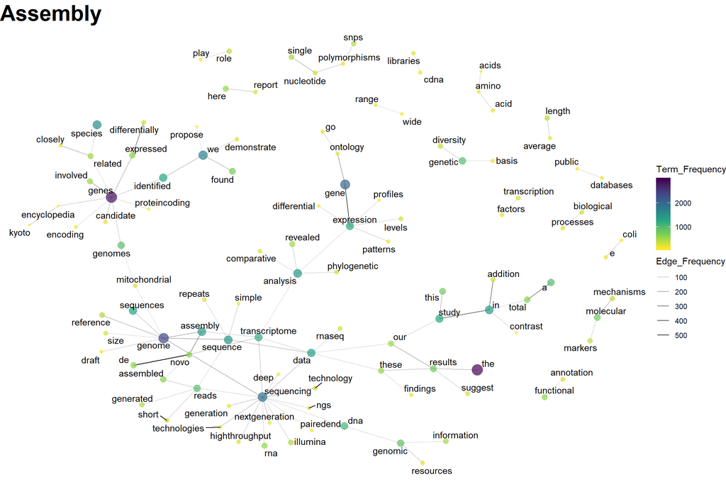

```r
#visualize_bigrams(df,abstract, "All Topics")
visualize_bigrams(df_assembly, abstract, "Assembly")
```

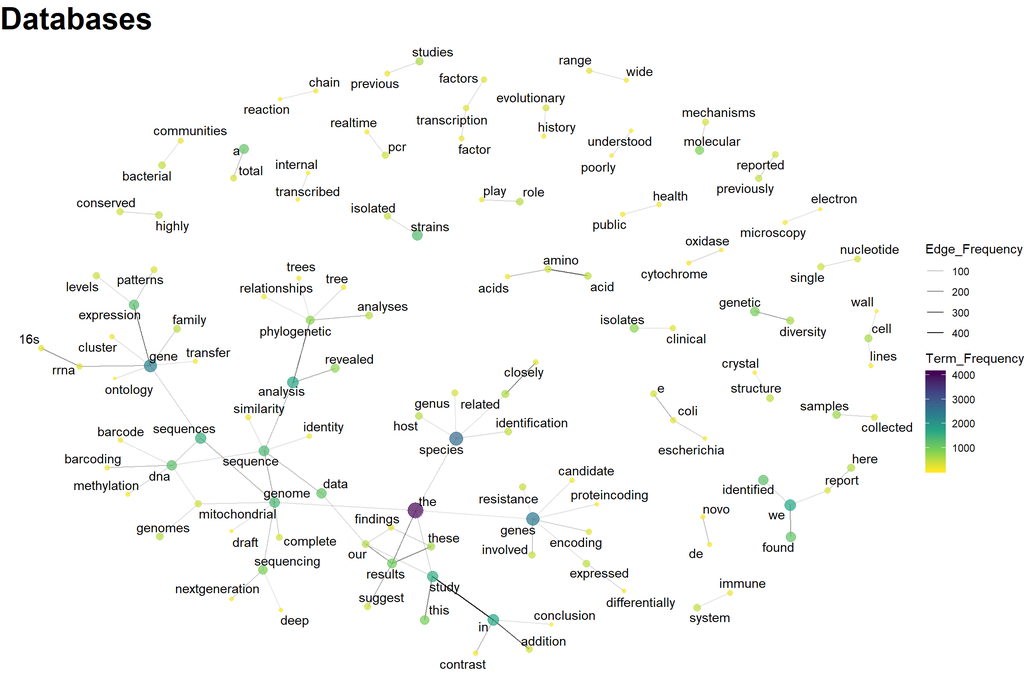

```r
visualize_bigrams(df_databases, abstract, "Databases")
```

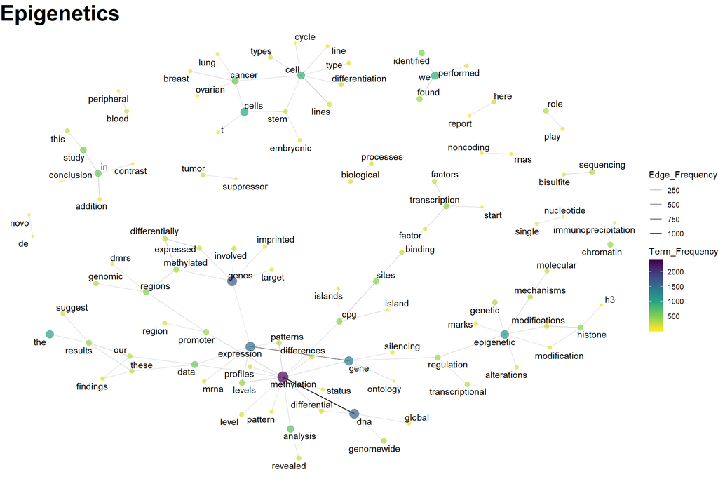

```r
visualize_bigrams(df_epigenetics, abstract, "Epigenetics")
```

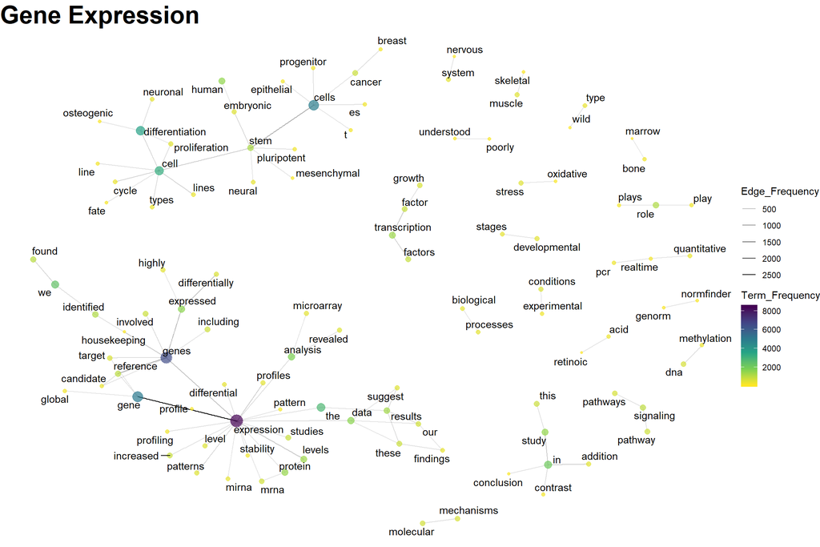

```r
visualize_bigrams(df_geneexp, abstract, "Gene Expression")
```

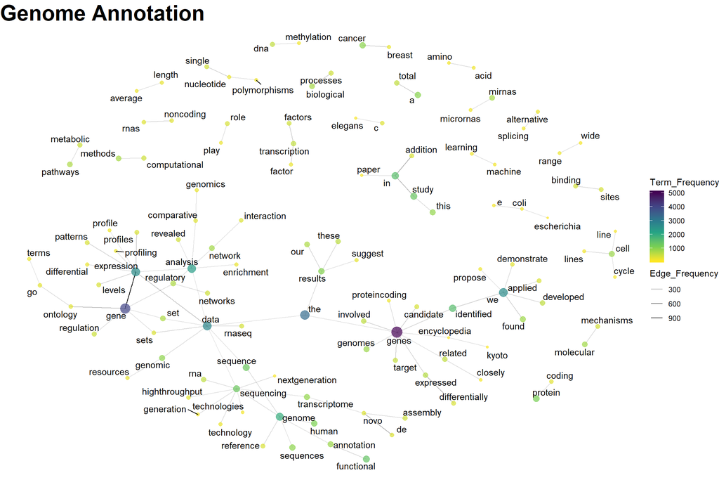

```r
visualize_bigrams(df_genomeann, abstract, "Genome Annotation")
```

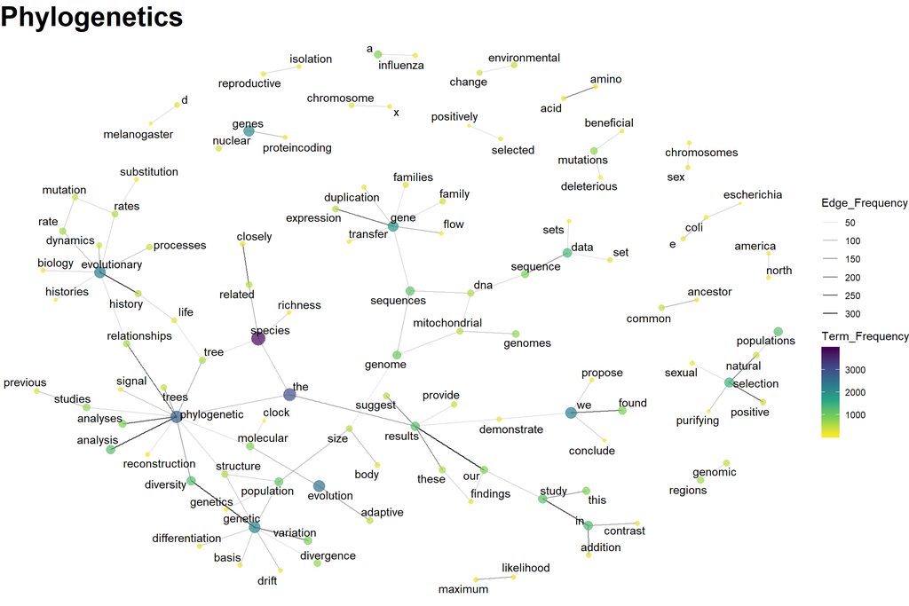

```r
visualize_bigrams(df_phylogenetics, abstract, "Phylogenetics")
```

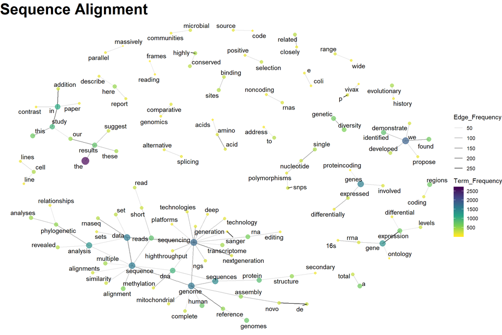

```r
visualize_bigrams(df_seqal, abstract, "Sequence Alignment")
```

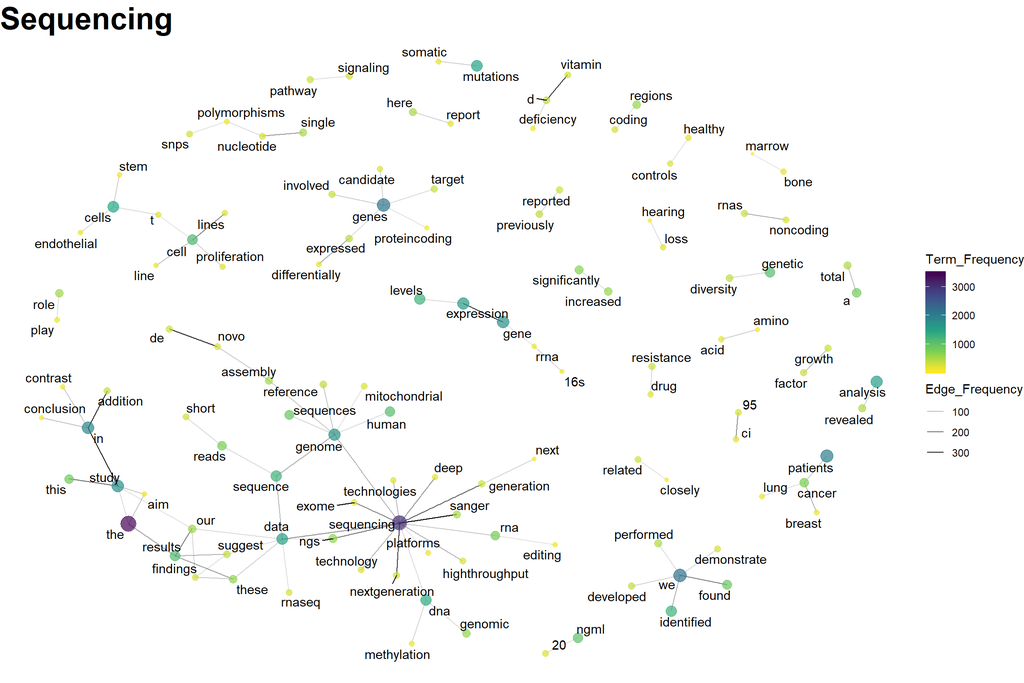

```r
visualize_bigrams(df_sequence, abstract, "Sequencing")
```

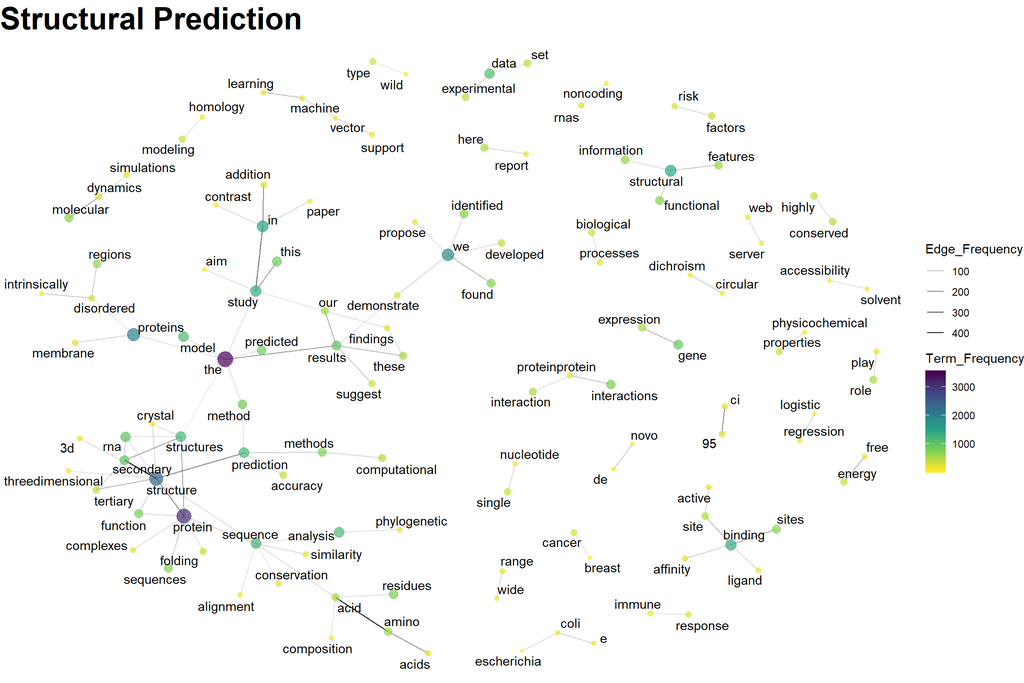

```r
visualize_bigrams(df_strucpred, abstract, "Structural Prediction")
```

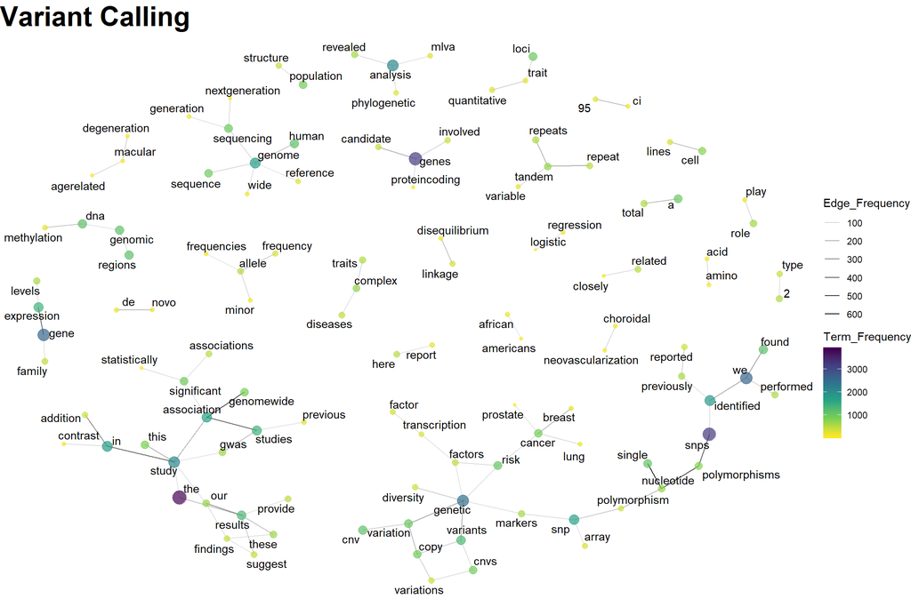

```r
visualize_bigrams(df_varcall, abstract, "Variant Calling")
```